# VLAD.FOSTER

Vlad

2022-11-06

### import the data

```r
foster <- read.csv("/Users/monikavlad/Desktop/dataset/Fc2020v1.csv")
```

###wrangling cleaning up caretaker family structure

```r
foster <- foster%>%
  filter(foster$ctkfamst %in% c("Married couple", "Unmarried couple", "Single female", "Single male"))
tab(foster, ctkfamst)
```

```
        ctkfamst │    Freq.  Percent     Cum.
─────────────────┼────────────────────────────
  Married couple │   106863    18.22    18.22
   Single female │   291552    49.72    67.94
     Single male │    34852     5.94    73.88
Unmarried couple │   153176    26.12   100.00
```

cleaning up race variable

```r
foster <- foster%>%
  filter(foster$race %in% c("White", "Black or African American", "American Indian or Alaska Native", "Asian", "Hawaiian or Other Pacific Islander", "More Than One Race"))
tab(foster, race)
```

```
                              race │    Freq.  Percent     Cum.
───────────────────────────────────┼────────────────────────────
  American Indian or Alaska Native │    15743     2.78     2.78
                             Asian │     3231     0.57     3.35
         Black or African American │   136170    24.04    27.39
Hawaiian or Other Pacific Islander │     1898     0.34    27.73
                More Than One Race │    54412     9.61    37.33
                             White │   354932    62.67   100.00
```

```r
foster$race <- recode_factor(foster$race, "White"="White", "African American" = "Black or African American", "American Indian"="American Indian or Alaska Native", "Asian" = "Asian", "Pacific Islander" = "Hawaiian or Other Pacific Islander", "Multiple Race"="More Than One Race")
levels(foster$race)
```

```
[1] "White"                              "Black or African American"
[3] "American Indian or Alaska Native"   "Asian"
[5] "Hawaiian or Other Pacific Islander" "More Than One Race"
```

renaming names for race categories to preserve space on the poster

```r
foster$race <- recode_factor(foster$race, "White"="White", "Balck or African American" = "African American", "American Indian or Alaska Native" = "American Indian", "Asian" = "Asian", "Hawaiian or Other Pacific Islander" = "Pacific Islander", "More Than One Race" = "Multiple Race")
levels(foster$race)
```

```
[1] "White"                     "American Indian"
[3] "Asian"                     "Pacific Islander"
[5] "Multiple Race"             "Black or African American"
```

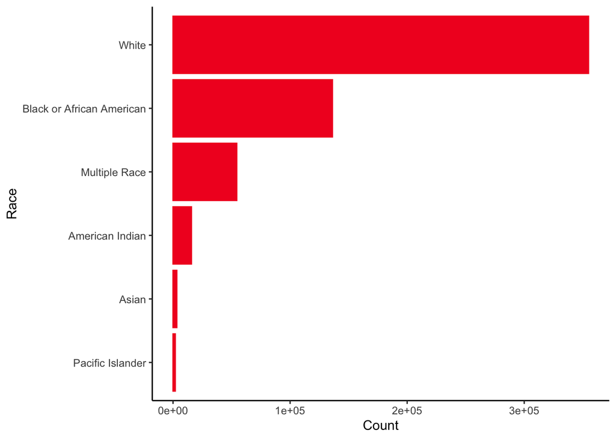

```r
reorder_size <- function(race) {
  factor(race, levels = names(sort(table(race), decreasing = FALSE)))
}
ggplot(foster, aes(x = reorder_size(race))) +
  geom_bar(color = "#F21D25", fill= "#F21D25") +
  theme(axis.text.x = element_text(angle = 90, hjust = 1)) +
  coord_flip() +
  labs(y = "Count", x = "Race") +
  theme_classic()+
  theme(legend.position = "none")
```

cleaning up physically disabled variable

```r
foster <- foster %>%
  filter(foster$phydis %in% c("Yes", "No"))
tab(foster, phydis)
```

```
phydis │    Freq.  Percent     Cum.
───────┼────────────────────────────
    No │   553699    99.01    99.01
   Yes │     5548     0.99   100.00
```

cleaning up gender

```r
foster <- foster %>%
  filter(foster$sex %in% c("Female", "Male"))
tab(foster, sex)
```

```
   sex │    Freq.  Percent     Cum.
───────┼────────────────────────────
Female │   272189    48.68    48.68
  Male │   286986    51.32   100.00
```

cleaning up clindis

```r
foster <- foster %>%
  filter(foster$clindis %in% c("Yes", "No"))
tab(foster, clindis)
```

```
clindis │    Freq.  Percent     Cum.
────────┼────────────────────────────
     No │   353457    73.11    73.11
    Yes │   129987    26.89   100.00
```

cleaning up mr

```r
foster <- foster %>%
  filter(foster$mr %in% c("Yes", "No"))
tab(foster, mr)
```

```
 mr │    Freq.  Percent     Cum.
────┼────────────────────────────
 No │   467022    96.60    96.60
Yes │    16422     3.40   100.00
```

cleaning up vishear

```r
foster <- foster %>%
  filter(foster$vishear %in% c("Yes", "No"))
tab(foster, vishear)
```

```
vishear │    Freq.  Percent     Cum.
────────┼────────────────────────────
     No │   470859    97.40    97.40
    Yes │    12584     2.60   100.00
```

cleaning up PhyAbuse

```r
foster <- foster %>%
  filter(foster$phyabuse %in% c("Yes", "No"))
tab(foster, phyabuse)
```

```
phyabuse │    Freq.  Percent     Cum.
─────────┼────────────────────────────
      No │   419091    86.86    86.86
     Yes │    63377    13.14   100.00
```

cleaning up neglect

```r
foster <- foster %>%
  filter(foster$neglect %in% c("Yes", "No"))
tab(foster, neglect)
```

```
neglect │    Freq.  Percent     Cum.
────────┼────────────────────────────
     No │   168006    34.82    34.82
    Yes │   314462    65.18   100.00
```

cleaning up manner of removal

```r
foster <- foster %>%
  filter(foster$manrem %in% c("Court ordered", "Voluntary"))
tab(foster, manrem)
```

```
       manrem │    Freq.  Percent     Cum.
──────────────┼────────────────────────────
Court ordered │   467743    97.77    97.77
    Voluntary │    10674     2.23   100.00
```

view sexabuse

```r
tab(foster, sexabuse)
```

```
sexabuse │    Freq.  Percent     Cum.
─────────┼────────────────────────────
      No │   458158    95.77    95.77
     Yes │    20259     4.23   100.00
```

view aaparent

```r
tab(foster, aaparent)
```

```
aaparent │    Freq.  Percent     Cum.
─────────┼────────────────────────────
      No │   451809    94.44    94.44
     Yes │    26608     5.56   100.00
```

view daparent

```r
tab(foster, daparent)
```

```
daparent │    Freq.  Percent     Cum.
─────────┼────────────────────────────
      No │   303679    63.48    63.48
     Yes │   174738    36.52   100.00
```

view aachil

```r
tab(foster, aachild)
```

```
aachild │    Freq.  Percent     Cum.
────────┼────────────────────────────
     No │   476802    99.66    99.66
    Yes │     1615     0.34   100.00
```

view dachild

```r
tab(foster, dachild)
```

```
dachild │    Freq.  Percent     Cum.
────────┼────────────────────────────
     No │   469063    98.04    98.04
    Yes │     9354     1.96   100.00
```

view childis

```r
tab(foster, childis)
```

```
childis │    Freq.  Percent     Cum.
────────┼────────────────────────────
     No │   469955    98.23    98.23
    Yes │     8462     1.77   100.00
```

view chbehprb

```r
tab(foster, chbehprb)
```

```
chbehprb │    Freq.  Percent     Cum.
─────────┼────────────────────────────
      No │   442579    92.51    92.51
     Yes │    35838     7.49   100.00
```

view prtsjail

```r
tab(foster, prtsjail)
```

```
prtsjail │    Freq.  Percent     Cum.
─────────┼────────────────────────────
      No │   447100    93.45    93.45
     Yes │    31317     6.55   100.00
```

view abandmnt

```r
tab(foster, abandmnt)
```

```
abandmnt │    Freq.  Percent     Cum.
─────────┼────────────────────────────
      No │   454431    94.99    94.99
     Yes │    23986     5.01   100.00
```

view housing

```r
tab(foster, housing)
```

```
housing │    Freq.  Percent     Cum.
────────┼────────────────────────────
     No │   423779    88.58    88.58
    Yes │    54638    11.42   100.00
```

view LifeLOS

```r
sum_up(foster, lifelos)
```

```
Variable │      Obs  Missing     Mean   StdDev      Min      Max
─────────┼───────────────────────────────────────────────────────
 lifelos │   456278    22139  730.216  705.173        0     7670
```